# Harbour Seal Ontogenetic Diet Hybrid Models (haddock grouped with pollock/haddock)

Author

Max Lindmark & Monica Mion

Published

August 14, 2026

## Purpose

This notebook focuses on ontogenetic variation in diet composition using a hybrid prey-group workflow that splits dominant gadid prey while keeping non-gadid prey grouped at family level. Compared with the base hybrid notebook, confidently identified haddock (`Melanogrammus aeglefinus`) is grouped together with the combined `Pollachius sp. / Melanogrammus aeglefinus` label rather than being pooled into `Other Gadidae`.

The workflow is:

- retain colonies through Onsala only,
- retain hunted seals only,
- keep the same dominant non-gadid family grouping as `03b`,
- split `Gadidae` into the most supported scientific-name labels,
- fold `Melanogrammus aeglefinus` (haddock) into the combined `Pollachius sp. / Melanogrammus aeglefinus` group,
- build a hunted-seal sample-by-hybrid-prey-group modelling table,
- test whether seal length changes diet composition,
- then test whether sex adds further structure once length is included.

```r
library(dplyr)
library(tidyr)
library(readr)
library(ggplot2)
library(forcats)
library(stringr)
library(janitor)
library(sf)
library(sdmTMB)
library(purrr)
library(rnaturalearth)
library(ggsidekick)
library(patchwork)

theme_set(theme_sleek())

home <- here::here()

biomass_file <- file.path(home, "Data", "HS_SKAG_estimated_abundance_biomass_130426.csv")

colony_keep <- c("Koster", "Vaderoarna", "Lysekil", "Marstrand", "Onsala")
analysis_year_min <- 2013L
dominant_families <- c("Gadidae", "Clupeidae", "Pleuronectidae", "Gobiidae")

family_palette <- c(
  "Gadidae"        = "#2E6B1F",
  "Clupeidae"      = "#1F5AA6",
  "Pleuronectidae" = "#D94FD3",
  "Gobiidae"       = "#F39C12",
  "Other"          = "#9E4A7A",
  "Total"          = "#000000"
)

prey_palette_9 <- c(
  "Gadus morhua"                          = "#0072B2",
  "Merlangius merlangus"                  = "#56B4E9",
  "Pollachius sp. / Melanogrammus aeglefinus" = "#009E73",
  "Gadidae"                               = "#F0E442",
  "Other Gadidae"                         = "#E69F00",
  "Clupeidae"                             = "#CC79A7",
  "Pleuronectidae"                        = "#D55E00",
  "Gobiidae"                              = "#999999",
  "Other"                                 = "#000000"
)

normalize_colony_name <- function(x) {
  x <- trimws(as.character(x))
  case_when(
    grepl("der.*arna", x, ignore.case = TRUE) ~ "Vaderoarna",
    grepl("^Hallands.*der", x, ignore.case = TRUE) ~ "Hallands Vadero",
    TRUE ~ x
  )
}
```

## Read and harmonize source data

```r
sample_meta_workbook <- read_csv(biomass_file, show_col_types = FALSE) |>
  clean_names() |>
  distinct(sample_id, .keep_all = TRUE) |>
  transmute(
    sample_id,
    year_wb = suppressWarnings(as.integer(year)),
    month_wb = suppressWarnings(as.integer(month)),
    quarter_wb = suppressWarnings(as.integer(quarter)),
    latitude_wb = suppressWarnings(as.numeric(latitude)),
    longitude_wb = suppressWarnings(as.numeric(longitude)),
    colony_wb = normalize_colony_name(colony),
    sex_wb = case_when(
      sex %in% c("Female", "Male") ~ as.character(sex),
      TRUE ~ NA_character_
    ),
    age_wb = suppressWarnings(as.numeric(age)),
    body_length_cm_wb = suppressWarnings(as.numeric(body_length_cm)),
    collection_method_wb = if_else(
      is.na(collection_method) | collection_method == "",
      "Unknown",
      as.character(collection_method)
    )
  )

diet_raw <- read_csv(biomass_file, show_col_types = FALSE) |>
  clean_names() |>
  left_join(sample_meta_workbook, by = "sample_id") |>
  mutate(
    year = coalesce(year_wb, suppressWarnings(as.integer(year))),
    month = coalesce(month_wb, suppressWarnings(as.integer(month))),
    quarter = coalesce(quarter_wb, suppressWarnings(as.integer(quarter))),
    latitude = coalesce(latitude_wb, suppressWarnings(as.numeric(latitude))),
    longitude = coalesce(longitude_wb, suppressWarnings(as.numeric(longitude))),
    colony = coalesce(colony_wb, normalize_colony_name(colony)),
    collection_method = coalesce(collection_method_wb, as.character(collection_method)),
    collection_method = if_else(is.na(collection_method) | collection_method == "", "Unknown", collection_method),
    family = if_else(is.na(family) | family == "", "Unknown", family),
    prey_species = prey_species_lat,
    sex = coalesce(sex_wb, case_when(
      sex %in% c("Female", "Male") ~ as.character(sex),
      TRUE ~ NA_character_
    )),
    age = coalesce(age_wb, suppressWarnings(as.numeric(age))),
    body_length_cm = coalesce(body_length_cm_wb, suppressWarnings(as.numeric(body_length_cm))),
    quarter = coalesce(quarter, ((month - 1L) %/% 3L) + 1L)
  ) |>
  select(-ends_with("_wb"))

sample_meta_all <- diet_raw |>
  filter(!is.na(sample_id), !is.na(year), !is.na(latitude), !is.na(longitude)) |>
  distinct(sample_id, .keep_all = TRUE) |>
  transmute(
    sample_id,
    year,
    month,
    quarter,
    lat = latitude,
    lon = longitude,
    collection_method,
    colony,
    sex,
    age,
    body_length_cm
  )

diet_rows_all <- diet_raw |>
  filter(
    !is.na(sample_id),
    !is.na(biomass_not_corrected),
    !is.na(prey_species),
    prey_species != "",
    tolower(prey_species) != "non prey item"
  ) |>
  transmute(
    sample_id,
    family,
    biomass_kg = biomass_not_corrected / 1000
  ) |>
  summarise(biomass_kg = sum(biomass_kg, na.rm = TRUE), .by = c(sample_id, family))

sample_totals_all <- diet_rows_all |>
  summarise(sum_biomass_kg = sum(biomass_kg, na.rm = TRUE), .by = sample_id)

sample_meta_filtered <- sample_meta_all |>
  left_join(sample_totals_all, by = "sample_id") |>
  mutate(sum_biomass_kg = coalesce(sum_biomass_kg, 0)) |>
  filter(
    collection_method == "Hunt",
    colony %in% colony_keep,
    sum_biomass_kg > 0
  )

if (nrow(sample_meta_filtered) == 0) {
  stop("No hunted samples remain after filtering by colony and positive total biomass.")
}

analysis_year_max <- max(sample_meta_filtered$year, na.rm = TRUE)

sample_meta_main <- sample_meta_filtered |>
  filter(year >= analysis_year_min, year <= analysis_year_max)

diet_rows_main <- diet_rows_all |>
  semi_join(sample_meta_main, by = "sample_id")
```

## Support summaries and family grouping

```r
n_main_samples <- nrow(sample_meta_main)

family_levels <- unique(c(dominant_families, "Other"))

family_support_main <- diet_rows_main |>
  summarise(
    total_biomass_kg = sum(biomass_kg, na.rm = TRUE),
    n_samples_present = n_distinct(sample_id[biomass_kg > 0]),
    .by = family
  ) |>
  mutate(
    prevalence = n_samples_present / n_main_samples,
    zero_rate = 1 - prevalence
  ) |>
  arrange(desc(total_biomass_kg))

diet_rows_grouped <- diet_rows_main |>
  mutate(family = if_else(family %in% dominant_families, family, "Other")) |>
  summarise(biomass_kg = sum(biomass_kg, na.rm = TRUE), .by = c(sample_id, family))

family_support_grouped <- diet_rows_grouped |>
  summarise(
    total_biomass_kg = sum(biomass_kg, na.rm = TRUE),
    n_samples_present = n_distinct(sample_id[biomass_kg > 0]),
    .by = family
  ) |>
  mutate(
    prevalence = n_samples_present / n_main_samples,
    zero_rate = 1 - prevalence,
    family = factor(family, levels = family_levels)
  ) |>
  arrange(family)
```

## Build hunted-only model table

```r
year_center <- mean(sample_meta_main$year, na.rm = TRUE)

diet_model_all <- sample_meta_main |>
  select(sample_id, year, month, quarter, lat, lon, colony, sum_biomass_kg, sex, age, body_length_cm) |>
  expand_grid(family = family_levels) |>
  left_join(diet_rows_grouped, by = c("sample_id", "family")) |>
  mutate(
    biomass_kg = coalesce(biomass_kg, 0),
    present = as.integer(biomass_kg > 0),
    prop_biomass = if_else(sum_biomass_kg > 0, biomass_kg / sum_biomass_kg, 0),
    year_ct = year - year_center,
    colony = factor(colony, levels = colony_keep),
    family = factor(family, levels = family_levels),
    sex = factor(sex, levels = c("Female", "Male")),
    year_f = factor(year),
    quarter_f = factor(quarter),
    month_f = factor(month)
  ) |>
  add_utm_columns(ll_names = c("lon", "lat"))

diet_model <- diet_model_all |>
  filter(!is.na(body_length_cm))

diet_model_sex <- diet_model |>
  filter(!is.na(sex))

diet_model |>
  summarise(
    n_samples = n_distinct(sample_id),
    n_rows = n(),
    min_year = min(year),
    max_year = max(year),
    n_families = n_distinct(family),
    length_min = min(body_length_cm),
    length_max = max(body_length_cm)
  )
```

```
# A tibble: 1 x 7
  n_samples n_rows min_year max_year n_families length_min length_max
      <int>  <int>    <int>    <int>      <int>      <dbl>      <dbl>
1       388   1940     2013     2025          5         80        203
```

## Support diagnostics

```r
hunt_samples_by_year <- sample_meta_main |>
  count(year, name = "n_samples")

missing_covariates <- sample_meta_main |>
  summarise(
    n_samples = n(),
    n_length = sum(!is.na(body_length_cm)),
    n_sex = sum(!is.na(sex)),
    n_age = sum(!is.na(age)),
    n_length_sex = sum(!is.na(body_length_cm) & !is.na(sex)),
    n_all_three = sum(!is.na(body_length_cm) & !is.na(sex) & !is.na(age))
  )

age_length_plot <- sample_meta_main |>
  filter(!is.na(body_length_cm), !is.na(age), !is.na(sex)) |>
  ggplot(aes(age, body_length_cm, color = sex)) +
  geom_point(alpha = 0.6) +
  geom_smooth(method = "lm", se = FALSE, linewidth = 1) +
  labs(
    title = "Relation between seal age and length",
    subtitle = "Separate fitted lines for female and male hunted seals",
    x = "Age",
    y = "Body length (cm)",
    color = "Sex"
  )

length_histogram <- sample_meta_main |>
  filter(!is.na(body_length_cm)) |>
  ggplot(aes(body_length_cm)) +
  geom_histogram(binwidth = 5, color = "white", fill = "grey40") +
  labs(
    title = "Seal length distribution in hunted samples",
    x = "Body length (cm)",
    y = "Samples"
  )

length_histogram_sex_colony <- sample_meta_main |>
  filter(!is.na(body_length_cm), !is.na(sex)) |>
  mutate(colony = factor(colony, levels = colony_keep)) |>
  ggplot(aes(body_length_cm, fill = sex)) +
  geom_histogram(binwidth = 5, color = "white") +
  facet_wrap(~colony, ncol = 1, scales = "free_y") +
  labs(
    title = "Seal length distribution in hunted samples by colony and sex",
    subtitle = "Colonies ordered from north to south",
    x = "Body length (cm)",
    y = "Samples",
    fill = "Sex"
  )

length_by_year <- sample_meta_main |>
  filter(!is.na(body_length_cm)) |>
  ggplot(aes(year, body_length_cm)) +
  geom_point(alpha = 0.5) +
  geom_smooth(method = "lm", se = TRUE, color = "black") +
  labs(
    title = "Seal length over time",
    x = "Year",
    y = "Body length (cm)"
  )

sex_balance <- sample_meta_main |>
  filter(!is.na(sex)) |>
  count(sex) |>
  ggplot(aes(sex, n, fill = sex)) +
  geom_col(show.legend = FALSE) +
  labs(
    title = "Sex balance in hunted samples",
    x = NULL,
    y = "Samples"
  )

sex_balance_colony <- sample_meta_main |>
  filter(!is.na(sex)) |>
  mutate(colony = factor(colony, levels = colony_keep)) |>
  count(colony, sex, name = "n") |>
  group_by(colony) |>
  mutate(
    total_n = sum(n),
    prop = n / total_n
  ) |>
  ungroup() |>
  ggplot(aes(colony, prop, fill = sex)) +
  geom_col() +
  geom_text(
    data = ~ distinct(.x, colony, total_n),
    aes(x = colony, y = 1.02, label = total_n),
    inherit.aes = FALSE,
    vjust = 0
  ) +
  scale_y_continuous(
    labels = scales::percent_format(accuracy = 1),
    limits = c(0, 1.08),
    expand = c(0, 0)
  ) +
  labs(
    title = "Relative sex composition by colony",
    subtitle = "Numbers above bars show total hunted samples with known sex",
    x = NULL,
    y = "Relative abundance",
    fill = "Sex"
  )

family_support_plot <- family_support_grouped |>
  mutate(family = fct_reorder(as.character(family), total_biomass_kg)) |>
  ggplot(aes(total_biomass_kg, family)) +
  geom_col(fill = "steelblue") +
  labs(
    title = "Grouped prey families retained for modelling",
    subtitle = "Same dominant-family set as 03b",
    x = "Total biomass (kg)",
    y = NULL
  )

missing_covariates
```

```
# A tibble: 1 x 6
  n_samples n_length n_sex n_age n_length_sex n_all_three
      <int>    <int> <int> <int>        <int>       <int>
1       401      388   381   142          376         134
```

```r
hunt_samples_by_year
```

```
# A tibble: 13 x 2
    year n_samples
   <int>     <int>
 1  2013        43
 2  2014        77
 3  2015        55
 4  2016        44
 5  2017         2
 6  2018         3
 7  2019        15
 8  2020        46
 9  2021        28
10  2022         6
11  2023        37
12  2024        30
13  2025        15
```

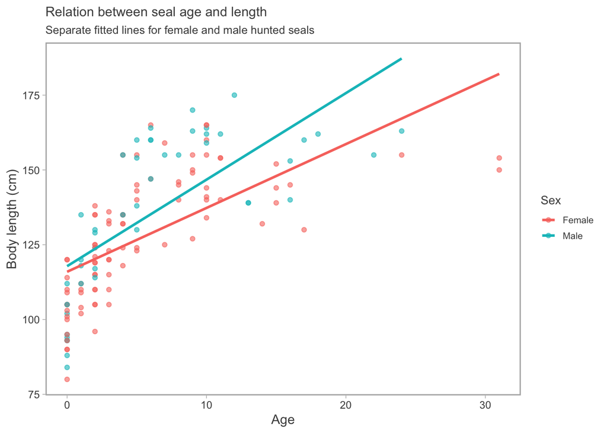

```r
age_length_plot
```

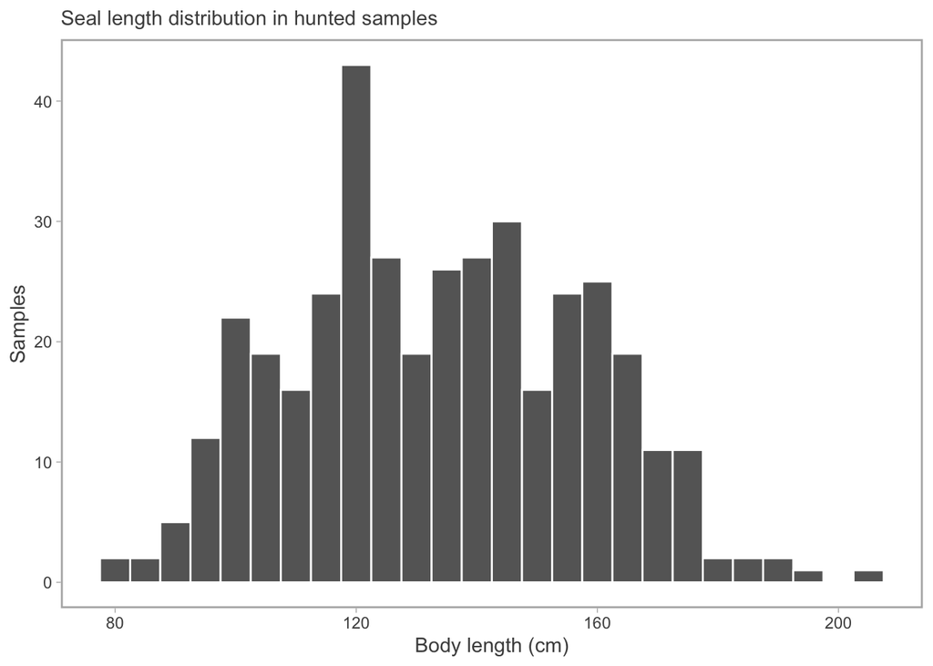

```r
length_histogram
```

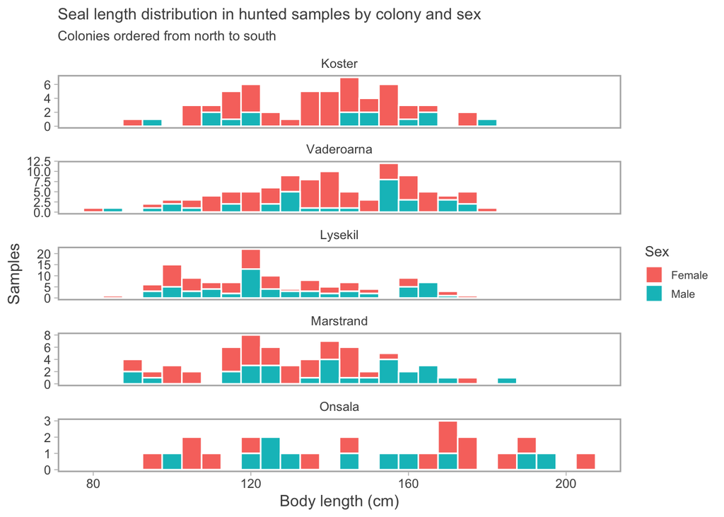

```r
length_histogram_sex_colony
```

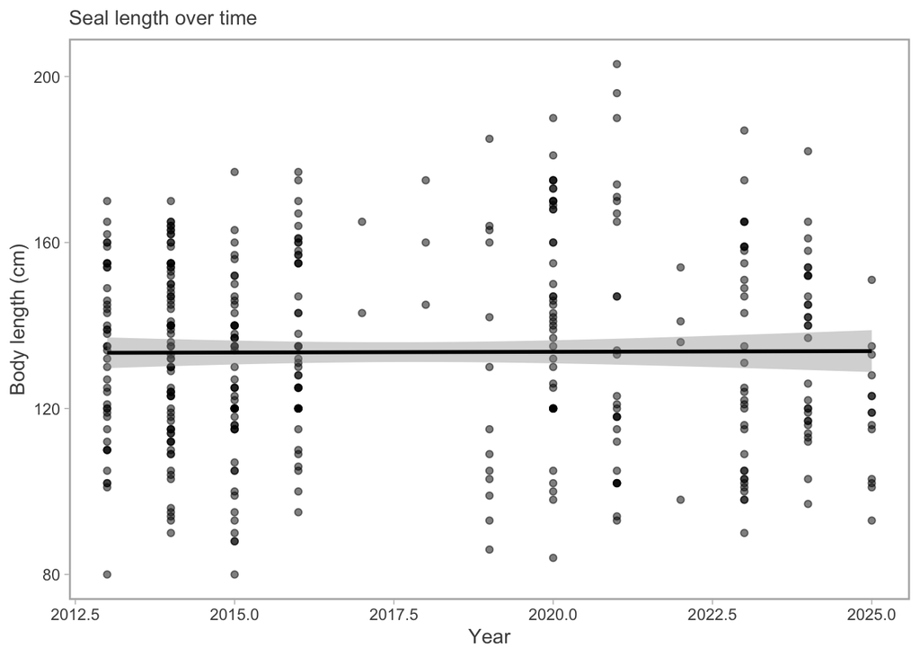

```r
length_by_year
```

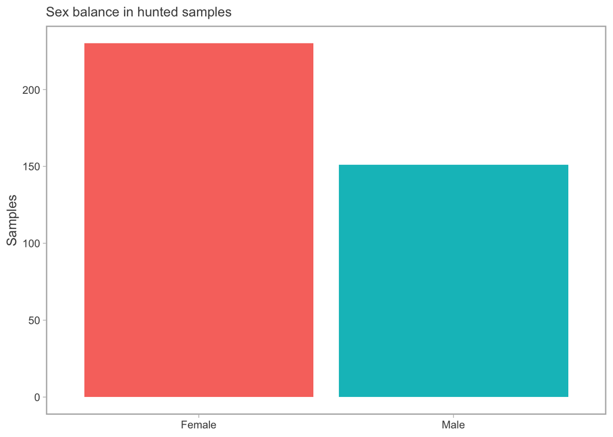

```r
sex_balance
```

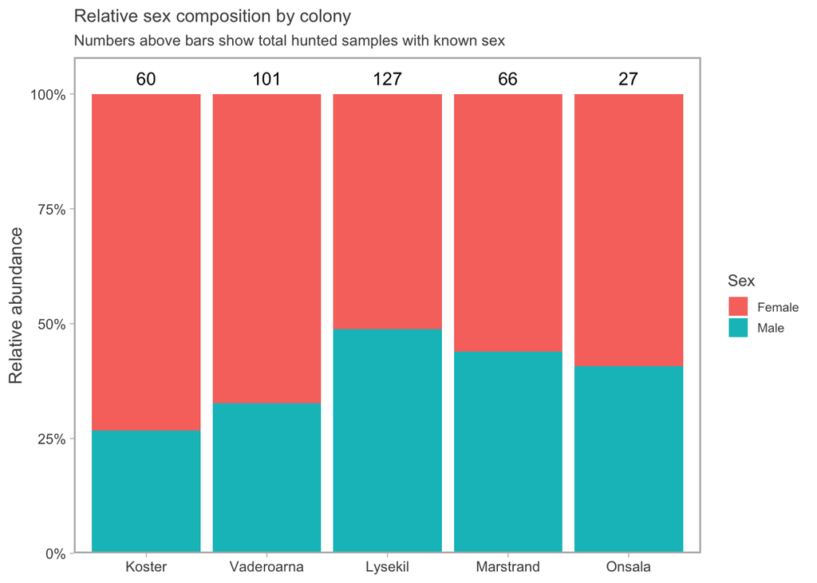

```r
sex_balance_colony
```

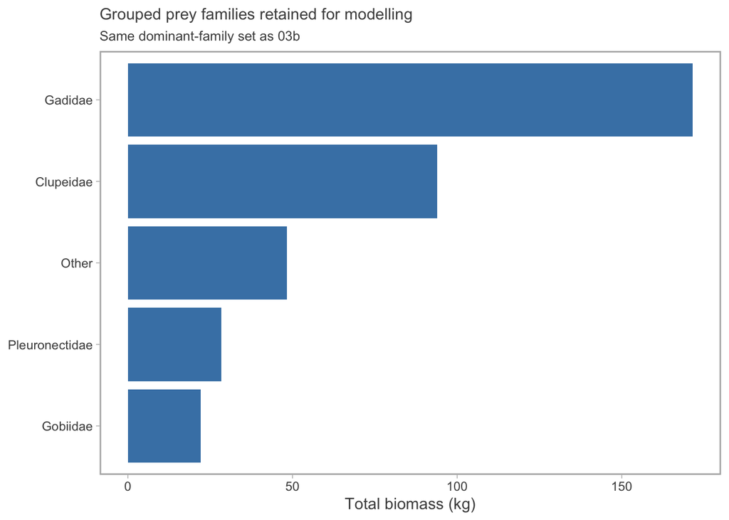

```r
family_support_plot
```

## Prediction grid

```r
d <- diet_model

hull_idx <- chull(d$X, d$Y)
hull_coords <- cbind(d$X[hull_idx], d$Y[hull_idx])
hull_coords <- rbind(hull_coords, hull_coords[1, ])

sp_poly <- sp::SpatialPolygons(
  list(sp::Polygons(list(sp::Polygon(hull_coords)), ID = 1))
)

sp_poly_df <- sp::SpatialPolygonsDataFrame(
  sp_poly,
  data = data.frame(ID = 1)
)

cell_width <- 0.5

pred_grid_base <- expand.grid(
  X = seq(min(d$X), max(d$X), cell_width),
  Y = seq(min(d$Y), max(d$Y), cell_width),
  year = seq(min(d$year), max(d$year))
)

sp::coordinates(pred_grid_base) <- c("X", "Y")

inside <- !is.na(sp::over(pred_grid_base, as(sp_poly_df, "SpatialPolygons")))

pred_grid_base <- pred_grid_base[inside, ]

pred_grid_base <- as.data.frame(pred_grid_base) |>
  mutate(
    year_ct = year - year_center,
    year_f = factor(year, levels = levels(diet_model$year_f))
  )

land <- ne_countries(scale = "large", returnclass = "sf") |>
  st_transform(32632)
```

## Mesh

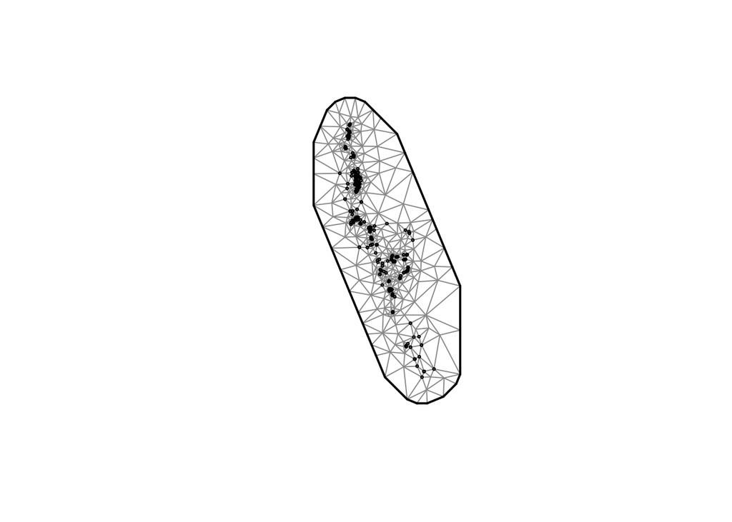

```r
mesh_cutoff_km <- 0.5

mesh <- make_mesh(diet_model, xy_cols = c("X", "Y"), type = "cutoff", cutoff = mesh_cutoff_km)

plot(mesh)
```

## Shared prediction reference

```r
prediction_reference <- sample_meta_main |>
  filter(!is.na(body_length_cm), !is.na(sex)) |>
  summarise(
    pred_year = round(median(sort(unique(year)))),
    pred_length_cm = median(body_length_cm, na.rm = TRUE)
  )

pred_year_common <- prediction_reference$pred_year
pred_length_common <- prediction_reference$pred_length_cm
```

## Hybrid prey-group questions: sex, length, year, space

This section uses one hybrid prey grouping for the hunted samples:

- split `Gadidae` into the most supported scientific-name labels,
- fold confidently identified `Melanogrammus aeglefinus` (haddock) into the combined `Pollachius sp. / Melanogrammus aeglefinus` group,
- keep the remaining gadids (`Trisopterus` spp., `Pollachius virens`, `Pollachius pollachius`, `Raniceps raninus`, `Gadiculus argenteus`) as `Other Gadidae`,
- keep non-gadid prey at the same grouped family level used above.

```r
gad_species_keep <- c(
  "Gadus morhua",
  "Merlangius merlangus",
  "Pollachius sp. / Melanogrammus aeglefinus",
  "Gadidae"
)

prey_group_levels <- c(
  gad_species_keep,
  "Other Gadidae",
  "Clupeidae",
  "Pleuronectidae",
  "Gobiidae",
  "Other"
)

hybrid_rows <- diet_raw |>
  filter(
    !is.na(sample_id),
    !is.na(biomass_not_corrected),
    !is.na(prey_species),
    prey_species != "",
    tolower(prey_species) != "non prey item"
  ) |>
  transmute(
    sample_id,
    prey_group = case_when(
      family == "Gadidae" & prey_species %in% gad_species_keep ~ prey_species,
      family == "Gadidae" & prey_species == "Melanogrammus aeglefinus" ~ "Pollachius sp. / Melanogrammus aeglefinus",
      family == "Gadidae" ~ "Other Gadidae",
      family == "Clupeidae" ~ "Clupeidae",
      family == "Pleuronectidae" ~ "Pleuronectidae",
      family == "Gobiidae" ~ "Gobiidae",
      TRUE ~ "Other"
    ),
    biomass_kg = biomass_not_corrected / 1000
  ) |>
  summarise(biomass_kg = sum(biomass_kg, na.rm = TRUE), .by = c(sample_id, prey_group))

prey_group_support <- hybrid_rows |>
  semi_join(sample_meta_main |> filter(!is.na(body_length_cm), !is.na(sex)), by = "sample_id") |>
  summarise(
    total_biomass_kg = sum(biomass_kg, na.rm = TRUE),
    n_samples_present = n_distinct(sample_id[biomass_kg > 0]),
    .by = prey_group
  ) |>
  mutate(prey_group = factor(prey_group, levels = prey_group_levels)) |>
  arrange(prey_group)

diet_model_hybrid <- sample_meta_main |>
  filter(!is.na(body_length_cm), !is.na(sex)) |>
  select(sample_id, year, month, quarter, lat, lon, colony, sum_biomass_kg, sex, body_length_cm) |>
  expand_grid(prey_group = prey_group_levels) |>
  left_join(hybrid_rows, by = c("sample_id", "prey_group")) |>
  mutate(
    biomass_kg = coalesce(biomass_kg, 0),
    year_ct = year - year_center,
    year_f = factor(year),
    quarter_f = factor(quarter),
    prey_group = factor(prey_group, levels = prey_group_levels),
    sex = factor(sex, levels = c("Female", "Male"))
  ) |>
  add_utm_columns(ll_names = c("lon", "lat"))

prey_group_support
```

```
# A tibble: 9 x 3
  prey_group                                total_biomass_kg n_samples_present
  <fct>                                                <dbl>             <int>
1 Gadus morhua                                          57.1               125
2 Merlangius merlangus                                  37.2               120
3 Pollachius sp. / Melanogrammus aeglefinus             35.5               101
4 Gadidae                                               24.5               142
5 Other Gadidae                                         10.3                84
6 Clupeidae                                             86.1               241
7 Pleuronectidae                                        22.6                72
8 Gobiidae                                              22.0               115
9 Other                                                 46.5               145
```

## Dataset summary

Counts and summary statistics for the modelling dataset (`diet_model_hybrid`): hunted seals with complete body length and sex, positive total biomass, 2013 onward, retained colonies only.

```r
n_model_samples <- n_distinct(diet_model_hybrid$sample_id)
n_model_rows <- nrow(diet_model_hybrid)

summary_samples <- diet_model_hybrid |>
  distinct(sample_id, year, quarter, sex, body_length_cm) |>
  summarise(
    n_samples = n(),
    n_female = sum(sex == "Female"),
    n_male = sum(sex == "Male"),
    length_min_cm = min(body_length_cm),
    length_median_cm = median(body_length_cm),
    length_max_cm = max(body_length_cm),
    year_min = min(year),
    year_max = max(year)
  )

summary_samples |>
  pivot_longer(everything(), names_to = "statistic", values_to = "value")
```

```
# A tibble: 8 x 2
  statistic        value
  <chr>            <dbl>
1 n_samples          376
2 n_female           229
3 n_male             147
4 length_min_cm       80
5 length_median_cm   133
6 length_max_cm      203
7 year_min          2013
8 year_max          2025
```

```r
summary_length_sex <- diet_model_hybrid |>
  distinct(sample_id, sex, body_length_cm) |>
  summarise(
    n = n(),
    length_min_cm = min(body_length_cm),
    length_median_cm = median(body_length_cm),
    length_max_cm = max(body_length_cm),
    .by = sex
  )

summary_quarter <- diet_model_hybrid |>
  distinct(sample_id, quarter_f) |>
  count(quarter_f, name = "n_samples")

summary_prey <- diet_model_hybrid |>
  summarise(
    n_present = sum(biomass_kg > 0),
    n_zero = sum(biomass_kg == 0),
    total_biomass_kg = sum(biomass_kg, na.rm = TRUE),
    .by = prey_group
  ) |>
  mutate(
    prevalence = n_present / n_model_samples,
    prey_group = factor(prey_group, levels = prey_group_levels)
  ) |>
  arrange(prey_group)

tibble(
  n_model_samples = n_model_samples,
  n_prey_groups = length(prey_group_levels),
  n_rows = n_model_rows,
  n_zero_rows = sum(diet_model_hybrid$biomass_kg == 0),
  n_nonzero_rows = sum(diet_model_hybrid$biomass_kg > 0)
)
```

```
# A tibble: 1 x 5
  n_model_samples n_prey_groups n_rows n_zero_rows n_nonzero_rows
            <int>         <int>  <int>       <int>          <int>
1             376             9   3384        2239           1145
```

```r
summary_length_sex
```

```
# A tibble: 2 x 5
  sex        n length_min_cm length_median_cm length_max_cm
  <fct>  <int>         <dbl>            <dbl>         <dbl>
1 Female   229            80              133           203
2 Male     147            84              133           196
```

```r
summary_quarter
```

```
# A tibble: 4 x 2
  quarter_f n_samples
  <fct>         <int>
1 1                93
2 2                75
3 3                67
4 4               141
```

```r
summary_prey
```

```
# A tibble: 9 x 5
  prey_group                        n_present n_zero total_biomass_kg prevalence
  <fct>                                 <int>  <int>            <dbl>      <dbl>
1 Gadus morhua                            125    251             57.1      0.332
2 Merlangius merlangus                    120    256             37.2      0.319
3 Pollachius sp. / Melanogrammus a~       101    275             35.5      0.269
4 Gadidae                                 142    234             24.5      0.378
5 Other Gadidae                            84    292             10.3      0.223
6 Clupeidae                               241    135             86.1      0.641
7 Pleuronectidae                           72    304             22.6      0.191
8 Gobiidae                                115    261             22.0      0.306
9 Other                                   145    231             46.5      0.386
```

```r
mesh_hybrid <- make_mesh(diet_model_hybrid, xy_cols = c("X", "Y"), type = "cutoff", cutoff = mesh_cutoff_km)

diet_model_hybrid$body_length_cm_sc <- (diet_model_hybrid$body_length_cm - mean(diet_model_hybrid$body_length_cm)) / sd(diet_model_hybrid$body_length_cm)

h1 <- sdmTMB(
  formula = biomass_kg ~ sex * prey_group + body_length_cm_sc + (1 | year_f),
  data = diet_model_hybrid,
  mesh = mesh_hybrid,
  family = tweedie(),
  spatial = "on"
)

h2 <- sdmTMB(
  formula = biomass_kg ~ sex * prey_group + body_length_cm_sc * prey_group + (1 | year_f),
  data = diet_model_hybrid,
  mesh = mesh_hybrid,
  family = tweedie(),
  spatial = "on"
)

h3 <- sdmTMB(
  formula = biomass_kg ~ sex * prey_group + s(body_length_cm_sc, by = prey_group) + (1 | year_f),
  data = diet_model_hybrid,
  mesh = mesh_hybrid,
  family = tweedie(),
  spatial = "on"
)

h4 <- sdmTMB(
  formula = biomass_kg ~ sex * prey_group + body_length_cm_sc * sex + (1 | year_f),
  data = diet_model_hybrid,
  mesh = mesh_hybrid,
  family = tweedie(),
  spatial = "on"
)

h5 <- sdmTMB(
  formula = biomass_kg ~ sex * prey_group + body_length_cm_sc + (1 | year_f),
  data = diet_model_hybrid,
  mesh = mesh_hybrid,
  family = tweedie(),
  spatial = "off",
  spatial_varying = ~ 0 + prey_group
)

h6 <- sdmTMB(
  formula = biomass_kg ~ sex * prey_group + body_length_cm_sc * prey_group + (1 | year_f),
  data = diet_model_hybrid,
  mesh = mesh_hybrid,
  family = tweedie(),
  spatial = "off",
  spatial_varying = ~ 0 + prey_group
)

h7 <- sdmTMB(
  formula = biomass_kg ~ body_length_cm * prey_group * sex + (1 | year_f),
  data = diet_model_hybrid,
  mesh = mesh_hybrid,
  family = tweedie(),
  spatial = "off",
  spatial_varying = ~ 0 + prey_group
)

h8 <- sdmTMB(
  formula = biomass_kg ~ sex * prey_group + body_length_cm_sc * prey_group + (1 | year_f),
  data = diet_model_hybrid,
  mesh = mesh_hybrid,
  family = tweedie(),
  spatial = "off",
  spatiotemporal = "iid",
  time = "year",
  spatial_varying = ~ 0 + prey_group
)

h9 <- sdmTMB(
  formula = biomass_kg ~ sex * prey_group + quarter_f * sex + body_length_cm_sc * prey_group + (1 | year_f),
  data = diet_model_hybrid,
  mesh = mesh_hybrid,
  family = tweedie(),
  spatial = "off",
  spatial_varying = ~ 0 + prey_group
)

h10 <- sdmTMB(
  formula = biomass_kg ~ sex * prey_group + quarter_f +
    body_length_cm_sc * prey_group + (1 | year_f),
  data = diet_model_hybrid,
  mesh = mesh_hybrid,
  family = tweedie(),
  spatial = "off",
  spatial_varying = ~ 0 + prey_group
)

h11 <- sdmTMB(
  formula = biomass_kg ~ sex * prey_group + quarter_f * sex + body_length_cm_sc * prey_group + body_length_cm_sc * sex + (1 | year_f),
  data = diet_model_hybrid,
  mesh = mesh_hybrid,
  family = tweedie(),
  spatial = "off",
  spatial_varying = ~ 0 + prey_group
)

# Full model-comparison table including h11 (h9 is used for inference;
# h11 = h9 + body_length_cm_sc:sex and is used for all prediction figures).
# The spatiotemporal model h8 has the lowest AIC but no explicit season effect.
aic_hybrid <- tibble(
  Model = paste0("h", 1:11),
  AIC = map_dbl(list(h1, h2, h3, h4, h5, h6, h7, h8, h9, h10, h11), AIC)
) |>
  mutate(delta_AIC = AIC - min(AIC)) |>
  arrange(AIC)

print(aic_hybrid, digits = 5)
```

```
# A tibble: 11 x 3
   Model   AIC delta_AIC
   <chr> <dbl>     <dbl>
 1 h8    2754.      0
 2 h6    2756.      1.75
 3 h10   2757.      2.83
 4 h5    2761.      6.91
 5 h9    2762.      7.97
 6 h11   2764.      9.95
 7 h7    2767.     12.4
 8 h3    2961.    206.
 9 h2    2961.    207.
10 h1    2980.    225.
11 h4    2981.    227.
```

```r
# Direct h9 vs h11 comparison for the prediction-model decision.
aic_h9_h11 <- tibble(
  Model = c("h9", "h11"),
  AIC = c(AIC(h9), AIC(h11))
) |>
  mutate(delta_AIC = AIC - min(AIC))
aic_h9_h11
```

```
# A tibble: 2 x 3
  Model   AIC delta_AIC
  <chr> <dbl>     <dbl>
1 h9    2762.      0
2 h11   2764.      1.98
```

```r
# Maybe prey*quarter as well? Then we might just do a 3-way interaction, which may or may not be supported..
```

```r
# biomass_kg ~ sex * prey_group + quarter_f * sex + body_length_cm_sc * prey_group + (1 | year_f)
# tidy(h9) |> as.data.frame()
#
# # female, q1?
# ggeffects::ggpredict(h9, terms = c("quarter_f", "sex"))
#
# ggeffects::ggpredict(h9, terms = c("quarter_f", "sex")) |>
#   plot()
```

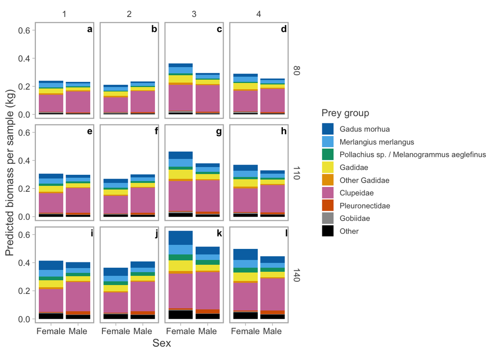

```r
pred_year_hybrid <- pred_year_common
pred_length_hybrid <- pred_length_common

# Season effects from the hybrid model using the same reference seal and year as the family plots.
nd_hybrid <- expand_grid(
  quarter_f = factor(c(1:4), levels = levels(diet_model_hybrid$quarter_f)),
  prey_group = factor(prey_group_levels, levels = prey_group_levels),
  sex = unique(diet_model_hybrid$sex),
  body_length_cm = c(80, 110, 140)
) |>
  mutate(
    body_length_cm_sc = (body_length_cm - mean(diet_model_hybrid$body_length_cm)) / sd(diet_model_hybrid$body_length_cm),
    year = pred_year_hybrid,
    year_ct = year - year_center,
    year_f = factor(year, levels = levels(diet_model_hybrid$year_f)),
    X = median(diet_model_hybrid$X, na.rm = TRUE),
    Y = median(diet_model_hybrid$Y, na.rm = TRUE)
  )

p_hybrid <- predict(h11, newdata = nd_hybrid, re_form = NA, re_form_iid = NA)

panel_tags <- expand_grid(
  body_length_cm = c(80, 110, 140),
  quarter_f = factor(1:4, levels = levels(diet_model_hybrid$quarter_f))
) |>
  mutate(tag = letters[seq_len(n())])

fig_sex_quarter <- ggplot(p_hybrid, aes(sex, exp(est), fill = prey_group)) +
  facet_grid(body_length_cm ~ quarter_f) +
  geom_bar(stat = "identity") +
  geom_text(
    data = panel_tags,
    aes(x = Inf, y = Inf, label = tag),
    hjust = 1.3, vjust = 1.4,
    inherit.aes = FALSE, size = 3.5, fontface = "bold"
  ) +
  scale_fill_manual(values = prey_palette_9) +
  labs(x = "Sex", y = "Predicted biomass per sample (kg)", fill = "Prey group")
fig_sex_quarter
```

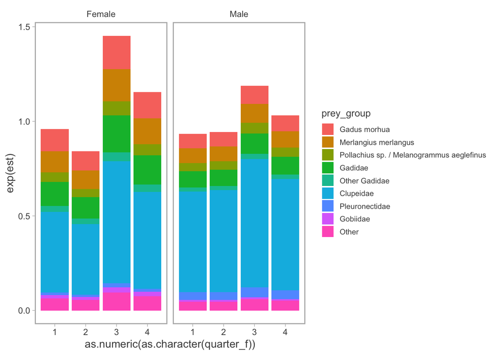

```r
ggplot(p_hybrid, aes(as.numeric(as.character(quarter_f)), exp(est), fill = prey_group)) +
  facet_wrap(~sex, ncol = 4) +
  geom_bar(stat = "identity")
```

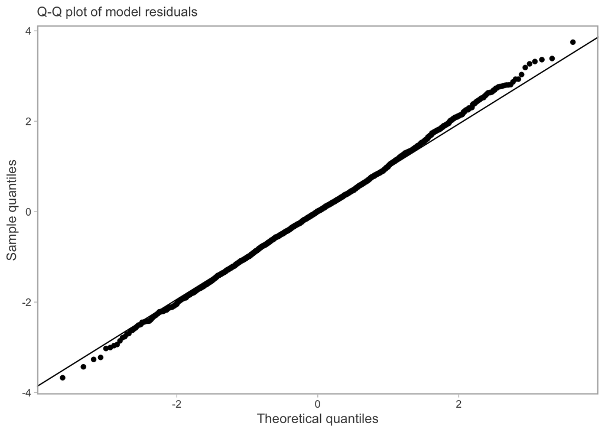

```r
fig_qqplot <- ggplot(data.frame(res = residuals(h11)), aes(sample = res)) +
  stat_qq() +
  stat_qq_line() +
  labs(x = "Theoretical quantiles", y = "Sample quantiles",
       title = "Q-Q plot of model residuals")
fig_qqplot
```

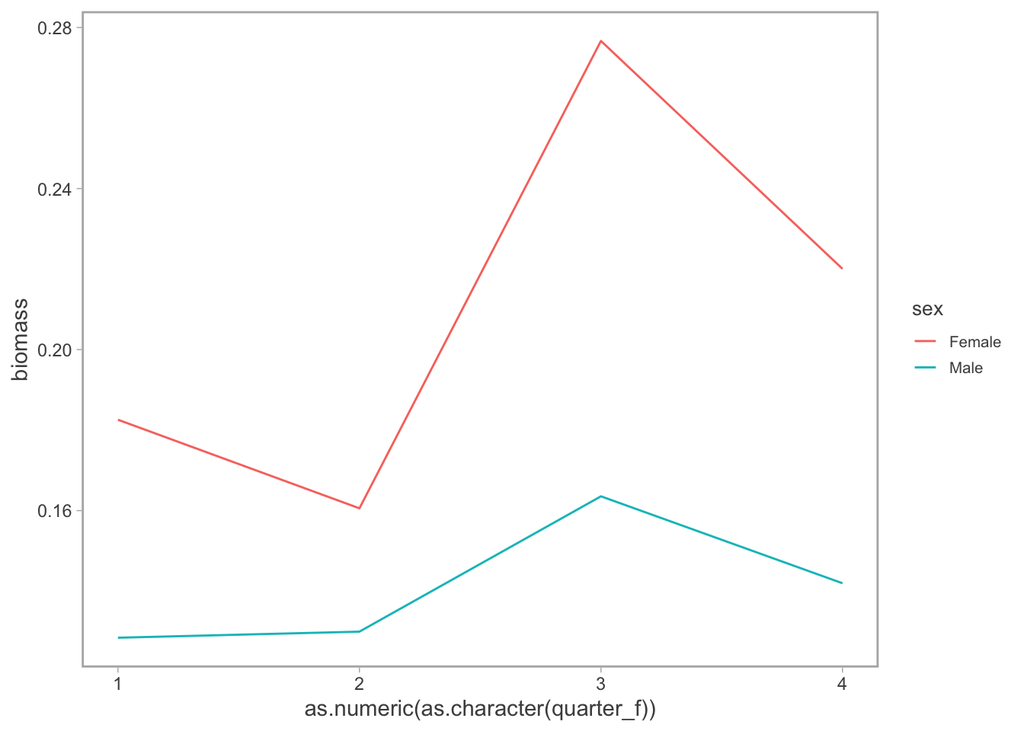

```r
# Quarter effect for aggregated gadid prey by sex at the same reference seal and year.
nd_hybrid_gad <- expand_grid(
  quarter_f = factor(c(1:4), levels = levels(diet_model_hybrid$quarter_f)),
  sex = unique(diet_model_hybrid$sex),
  prey_group = factor(c(gad_species_keep, "Other Gadidae"), levels = prey_group_levels)
) |>
  mutate(
    body_length_cm = pred_length_hybrid,
    body_length_cm_sc = (body_length_cm - mean(diet_model_hybrid$body_length_cm)) / sd(diet_model_hybrid$body_length_cm),
    year = pred_year_hybrid,
    year_ct = year - year_center,
    year_f = factor(year, levels = levels(diet_model_hybrid$year_f)),
    X = median(diet_model_hybrid$X, na.rm = TRUE),
    Y = median(diet_model_hybrid$Y, na.rm = TRUE)
  )

p_hybrid_gad <- predict(h11, newdata = nd_hybrid_gad, re_form = NA, re_form_iid = NA)

hybrid_gad_quarter <- nd_hybrid_gad |>
  bind_cols(as_tibble(p_hybrid_gad) |> select(est)) |>
  mutate(biomass = exp(est)) |>
  summarise(biomass = sum(biomass), .by = c(quarter_f, sex))

ggplot(hybrid_gad_quarter, aes(as.numeric(as.character(quarter_f)), biomass, color = sex)) +
  geom_line()
```

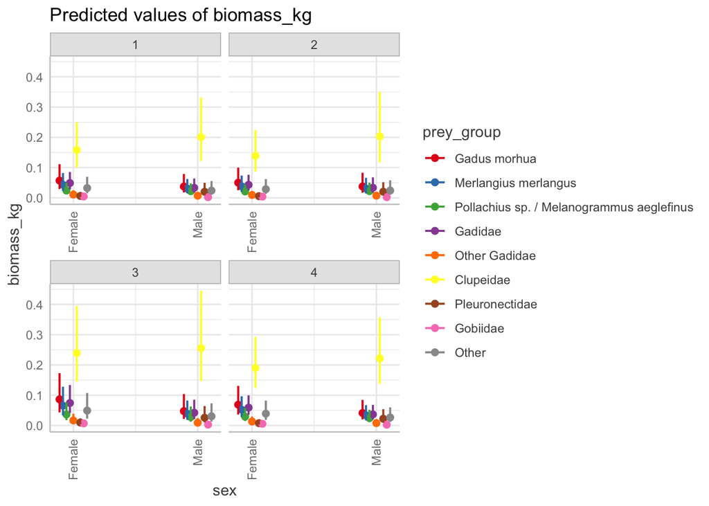

```r
plot(ggeffects::ggpredict(h11, c("sex", "prey_group", "quarter_f"))) +
  theme(axis.text.x = element_text(angle = 90, vjust = 0.5, hjust = 1))
```

```r
ggeffects::ggpredict(h11, c("sex"))
```

```
# Predicted values of biomass_kg

sex    | Predicted |     95% CI
-------------------------------
Female |      0.06 | 0.03, 0.11
Male   |      0.04 | 0.02, 0.08

Adjusted for:
*        prey_group = Gadus morhua
*         quarter_f =            1
* body_length_cm_sc =        -0.00
*            year_f =         2013
```

```r
ggeffects::ggpredict(h11, c("sex", "prey_group"))
```

```
# Predicted values of biomass_kg

prey_group: Gadus morhua

sex    | Predicted |     95% CI
-------------------------------
Female |      0.06 | 0.03, 0.11
Male   |      0.04 | 0.02, 0.08

prey_group: Merlangius merlangus

sex    | Predicted |     95% CI
-------------------------------
Female |      0.04 | 0.02, 0.08
Male   |      0.03 | 0.01, 0.06

prey_group: Pollachius sp. / Melanogrammus aeglefinus

sex    | Predicted |     95% CI
-------------------------------
Female |      0.02 | 0.01, 0.05
Male   |      0.02 | 0.01, 0.05

prey_group: Gadidae

sex    | Predicted |     95% CI
-------------------------------
Female |      0.05 | 0.03, 0.09
Male   |      0.03 | 0.02, 0.06

prey_group: Other Gadidae

sex    | Predicted |     95% CI
-------------------------------
Female |      0.01 | 0.00, 0.02
Male   |      0.01 | 0.00, 0.02

prey_group: Clupeidae

sex    | Predicted |     95% CI
```

[output cut: 14 more lines]

```
-------------------------------
Female |      0.00 | 0.00, 0.01
Male   |      0.00 | 0.00, 0.01

prey_group: Other

sex    | Predicted |     95% CI
-------------------------------
Female |      0.03 | 0.02, 0.07
Male   |      0.02 | 0.01, 0.06

Adjusted for:
*         quarter_f =     1
* body_length_cm_sc = -0.00
*            year_f =  2013
```

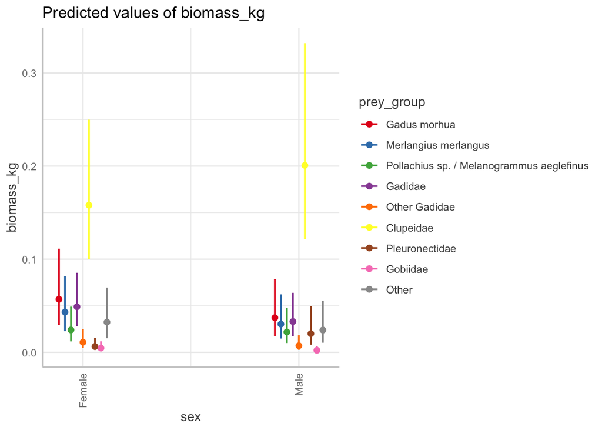

```r
plot(ggeffects::ggpredict(h11, c("sex", "prey_group"))) +
  theme(axis.text.x = element_text(angle = 90, vjust = 0.5, hjust = 1))
```

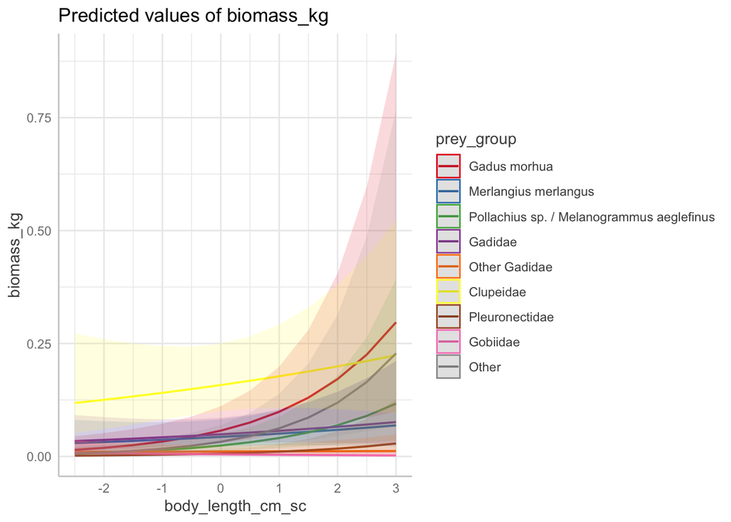

```r
plot(ggeffects::ggpredict(h11, c("body_length_cm_sc", "prey_group")))
```

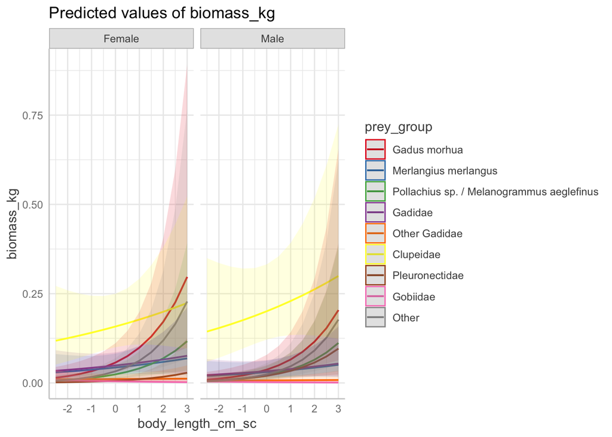

```r
plot(ggeffects::ggpredict(h11, c("body_length_cm_sc", "prey_group", "sex")))
```

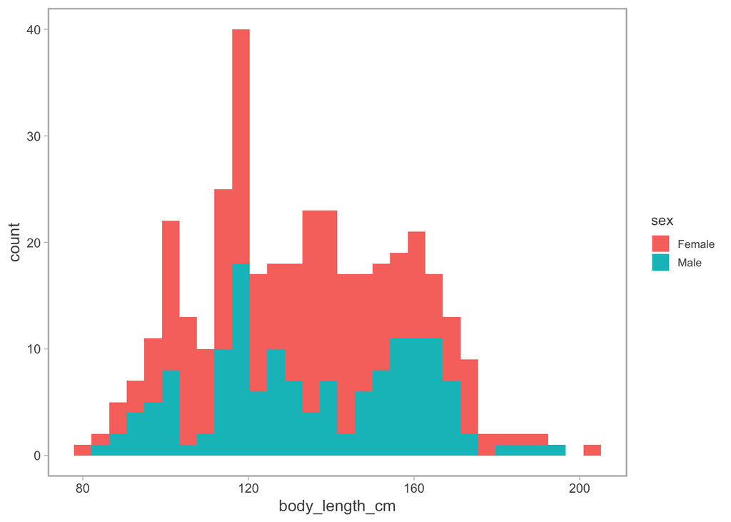

```r
diet_model_hybrid |>
  distinct(sample_id, body_length_cm, sex) |>
  ggplot(aes(body_length_cm, fill = sex)) +
  geom_histogram()
```

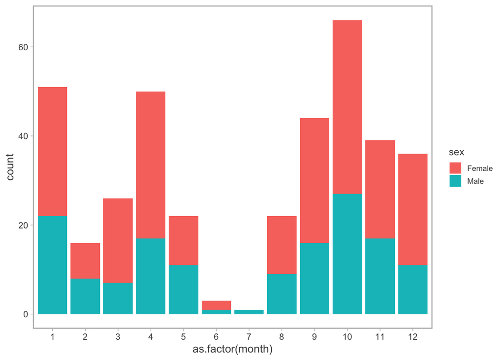

```r
diet_model_hybrid |>
  distinct(sample_id, month, sex) |>
  ggplot(aes(as.factor(month), fill = sex)) +
  geom_bar()
```

## h9 vs h11: why all prediction figures use h11

h9 is the model used for parameter inference and its equation is reported in the paper Methods. Note that the spatiotemporal model h8 has the lowest AIC overall but contains no explicit season effect; h9 is the best-supported model that retains an explicit season `x` sex interaction. All prediction figures (sex, length, quarter, space) are generated from h11, which adds a `body_length_cm_sc:sex` interaction to h9. The rationale:

1. **Biological motivation** — harbour seals are sexually size-dimorphic, and sex-specific length-biomass relationships are expected from sex-specific foraging behaviour and reproductive energetics. h11 was fitted to explicitly evaluate this biological hypothesis rather than to chase a lower AIC.
2. **Model-selection uncertainty** — h9 and h11 differ by a single interaction term (1 df). The $\Delta$AIC between them is small (see `aic_h9_h11`), so standard model-selection criteria do not clearly separate the two models.
3. **Prediction invariance** — the h9 and h11 predictions used in the figures are effectively identical (correlation and maximum relative difference below), so the figure pipeline is not affected by the choice between the two models.
4. **No untested constraint** — h9 forces the length effect to be identical for females and males for every prey group. h11 relaxes exactly this constraint for the sex-comparison figures being shown, which is the honest choice when the figures illustrate sex differences.

```r
# sex * length interaction estimate from h11
h11_sex_length <- tidy(h11, effects = "fixed", conf.int = TRUE) |>
  filter(grepl("body_length_cm_sc.*sexMale|sexMale.*body_length_cm_sc", term))
h11_sex_length
```

```
# A tibble: 1 x 5
  term                      estimate std.error conf.low conf.high
  <chr>                        <dbl>     <dbl>    <dbl>     <dbl>
1 sexMale:body_length_cm_sc   0.0173     0.111   -0.199     0.234
```

```r
# convergence checks
sanity(h9)
sanity(h11)

# Prediction invariance on the same grid used for Fig 2 (sex_quarter).
p_invar_h9 <- predict(h9, newdata = nd_hybrid, re_form = NA, re_form_iid = NA)
p_invar_h11 <- predict(h11, newdata = nd_hybrid, re_form = NA, re_form_iid = NA)

invar_check <- nd_hybrid |>
  mutate(
    pred_h9 = exp(p_invar_h9$est),
    pred_h11 = exp(p_invar_h11$est)
  ) |>
  summarise(
    cor = cor(pred_h9, pred_h11),
    max_abs_diff = max(abs(pred_h9 - pred_h11)),
    max_rel_diff = max(abs(pred_h9 - pred_h11) / pred_h9)
  )
invar_check
```

```
# A tibble: 1 x 3
    cor max_abs_diff max_rel_diff
  <dbl>        <dbl>        <dbl>
1 1.000      0.00476       0.0293
```

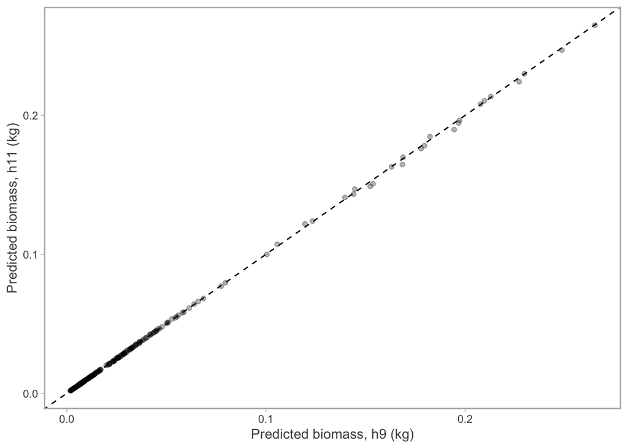

```r
p_invar <- nd_hybrid |>
  mutate(
    pred_h9 = exp(p_invar_h9$est),
    pred_h11 = exp(p_invar_h11$est)
  ) |>
  ggplot(aes(pred_h9, pred_h11)) +
  geom_abline(intercept = 0, slope = 1, lty = 2) +
  geom_point(alpha = 0.3) +
  labs(x = "Predicted biomass, h9 (kg)", y = "Predicted biomass, h11 (kg)")
p_invar
```

## Model details reported in the paper Methods and Results

Values used in the paper text (Methods: Tweedie power, year random intercept, mesh resolution; Results: h9 fixed-effect estimates with 95% CIs and variance components).

```r
h9_ran_pars <- tidy(h9, effects = "ran_pars") |>
  select(group_name, term, estimate) |>
  mutate(estimate = round(estimate, 4))

h9_ran_pars
```

```
# A tibble: 13 x 3
   group_name term            estimate
   <chr>      <chr>              <dbl>
 1 <NA>       range              3.04
 2 <NA>       phi                2.03
 3 <NA>       sigma_Z            1.82
 4 <NA>       sigma_Z            1.49
 5 <NA>       sigma_Z            1.81
 6 <NA>       sigma_Z            0.969
 7 <NA>       sigma_Z            1.71
 8 <NA>       sigma_Z            0.842
 9 <NA>       sigma_Z            2.19
10 <NA>       sigma_Z            2.58
11 <NA>       sigma_Z            2.07
12 <NA>       tweedie_p          1.63
13 year_f     sd__(Intercept)    0.229
```

```r
h9_ran_pars |>
  filter(term %in% c("tweedie_p", "phi", "sd__(Intercept)")) |>
  mutate(parameter = case_when(
    term == "tweedie_p" ~ "Tweedie power p",
    term == "phi" ~ "Tweedie dispersion",
    term == "sd__(Intercept)" ~ "Year random intercept SD"
  )) |>
  select(parameter, estimate)
```

```
# A tibble: 3 x 2
  parameter                estimate
  <chr>                       <dbl>
1 Tweedie dispersion          2.03
2 Tweedie power p             1.63
3 Year random intercept SD    0.229
```

```r
tibble(
  parameter = c("mesh_cutoff_km", "n_mesh_knots", "n_years"),
  value = c(mesh_cutoff_km, mesh_hybrid$mesh$n, n_distinct(diet_model_hybrid$year_f))
)
```

```
# A tibble: 3 x 2
  parameter      value
  <chr>          <dbl>
1 mesh_cutoff_km   0.5
2 n_mesh_knots   476
3 n_years         13
```

```r
h9_fixed <- tidy(h9, effects = "fixed", conf.int = TRUE) |>
  select(term, estimate, conf.low, conf.high) |>
  mutate(across(where(is.numeric), round, 3))
print(h9_fixed, n = 40)
```

```
# A tibble: 33 x 4
   term                                              estimate conf.low conf.high
   <chr>                                                <dbl>    <dbl>     <dbl>
 1 (Intercept)                                         -2.87    -3.54     -2.20
 2 sexMale                                             -0.421   -1.11      0.27
 3 prey_groupMerlangius merlangus                      -0.276   -1.10      0.543
 4 prey_groupPollachius sp. / Melanogrammus aeglefi~   -0.866   -1.74      0.006
 5 prey_groupGadidae                                   -0.152   -0.906     0.603
 6 prey_groupOther Gadidae                             -1.66    -2.63     -0.679
 7 prey_groupClupeidae                                  1.02     0.328     1.72
 8 prey_groupPleuronectidae                            -2.20    -3.23     -1.18
 9 prey_groupGobiidae                                  -2.52    -3.61     -1.44
10 prey_groupOther                                     -0.564   -1.48      0.346
11 quarter_f2                                          -0.124   -0.563     0.315
12 quarter_f3                                           0.422   -0.06      0.903
```

[output cut: 21 more lines]